# Workshop 5 - Confidence Intervals & t-tests in Jamovi

Research Methods and Statistics - T2 2026

**Introduction**

Hey team! Over the last two weeks of lectures you begun to build the hypothesis-testing toolkit: **confidence intervals** (Lecture 11), the **five steps of a significance test** (Lecture 12), and the three **t-tests** (Lectures 11, 12, 13). Today you run all three on data in Jamovi, check the assumptions yourself, and check our understanding of key concepts as we prepare for the final exam.

Every result today gets *interpreted* by asking the same **four interpretation questions**. We will use these again and again as we perform new tests each week. These are not the five steps of a significance test from Lecture 12 (assumptions → hypotheses → test statistic → p-value → conclusion); they are how you do the **fifth step** properly. Learn them now and they’ll carry you through ANOVA and chi-square later in the trimester.

**Significance**Is p < α? Reject or fail to reject H₀?

**Confidence interval**What range is plausible? Does it include 0 (or the hypothesised value)?

**Effect size**If significant, how *big* is it? (Cohen's d)

**Clinical meaning**Do the values matter in the real world?

You can come back to this page any time you need a reminder of how to run a t-test in Jamovi.

**What you’ll do today**

- Choose the right t-test from the research design/data
- Check the normality assumption with Shapiro–Wilk, histograms and Q-Q plots
- Run a one-sample, an independent samples and a paired samples t-test
- Read the output: t, df, p, the 95% CI and Cohen’s d (an effect size for a t-test)
- See why the CI and the p-value always agree, and why overlapping group CIs can still be “significant”
- Write up one result using the four interpretation questions structure

[figure not shown]

**A real-world example…** a sports scientist might use a **one-sample t-test** to ask whether elite athletes’ resting heart rates differ from the general-population average, an **independent samples t-test** to compare reaction times between gamers and non-gamers, and a **paired samples t-test** to test whether cholesterol changed after a new drug in the same patients. Same family of test, three different research designs.

## Why t-tests?

T-tests compare **means**. Our sample mean is only an estimate of the **population mean** (the parameter we really want to know), so a t-test asks whether the difference we observed is bigger than sampling variation alone would produce, and the CI gives the range of population means (or mean differences) consistent with the data. Which one you use is decided entirely by your **design**:

| Question | Test | What it compares |
| --- | --- | --- |
| *Does this group differ from a known/recommended value?* | **One-sample** | One sample mean vs. a fixed hypothesised value μ₀ (e.g. 7 h) |
| *Do two separate groups differ?* | **Independent samples** | Mean of group A vs. mean of group B (bet ween-subjects) |
| *Did the same people change between two conditions/times?* | **Paired samples** | Mean of the *within-person differences* vs. 0 |

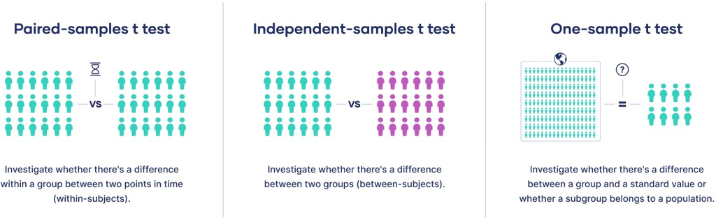

The three t-tests from three research designs.

**Why t and not z?** Remember from Lecture 13’s, we use a z-test only when the population SD (σ) is known, which is almost never. Everything today estimates σ from the sample SD (*s*), which adds uncertainty, so we use the t-distribution with its fatter tails and its degrees of freedom (df). With large samples t and z converge; with small samples t is deliberately more cautious/conservative.

## The t-test essentials

Work through these tabs before the tasks. They condense Lectures 11–13 into what you need at the keyboard (and in the exam).

**Which test?**

The choice is made by the **design**, not by the data. Ask two questions:

1. **How many groups/conditions?** One → *one-sample*. Two → next question.
2. **Are the two sets of scores from the *same* people (or matched pairs)?** Yes → *paired*. No → *independent*.

| Design cue in the scenario | Test |
| --- | --- |
| “compared to the recommended…”, “differ from the norm” | One-sample |
| “two groups”, “smokers vs non-smokers”, “between” | Independent samples |
| “before and after”, “each participant did both”, “matched pairs”, “cross-over” | Paired samples |

Quick-fire practice (three scenarios, no data needed):

Grip strength is measured in 18 netballers before and after a 6-week training block. Which test?

One-sample t-test Independent samples t-test Paired samples t-test

**Hint:** are the "before" scores and the "after" scores from the same people?

A dietitian records daily sodium intake in 40 tradies and asks whether it differs from the 2,000 mg guideline. Which test?

One-sample t-test Independent samples t-test Paired samples t-test

**Hint:** how many groups of people were measured? What is the 2,000 mg being compared against?

Reaction time is compared between 30 regular gamers and 30 non-gamers. Which test?

One-sample t-test Independent samples t-test Paired samples t-test

**Hint:** a gamer's score isn't linked to any particular non-gamer's score. They are unrelated groups.

**The five steps**

Every significance test follows the same recipe from Lecture 12. Jamovi does the arithmetic for steps 3 and 4; steps 1, 2 and 5 are **yours**.

| Step | What you do | Where it happens today |
| --- | --- | --- |
| 1. A ssumptions** | Continuous outcome, independent observations (design), approximately normal | Exploration ▸ Descriptives |
| 2. **Hypotheses** | H₀: no difference (μ = 7, μ₁ = μ₂, or μ_d = 0). Hₐ: a difference (≠, two-tailed) | Written *before* you analyse |
| 3. **Test statistic** | t = (observed difference) ÷ (standard error of that difference) | Jamovi output, `Statistic` |
| 4. **p-value** | Probability of a t at least this extreme *if H₀ were true*, using the t-distribution with df | Jamovi output, `p` |
| 5. **Conclusion** | Reject / fail to reject H₀, then interpret with CI, effect size and real-world context | Your write-up |

**Two-tailed by default.** All three research questions today ask whether there is *a difference*, not a difference in a specified direction, so Hₐ uses ≠ and α = 0.05 is split 0.025 into each tail. Lecture 13’s point still stands, even when you expect a direction, a two-tailed test is the conservative, widely accepted choice. It sets a higher bar to clear before we claim a difference, so a result that clears it is harder to argue with, and it can still detect an effect that turns out to run the opposite way to what we predicted.

**Assumptions**

T-tests are **parametric**, they assume the sampling distribution of the mean is normal. In practice we check the *data* (or the *differences*, for a paired test) three ways and read them together:

| Check | What to look for | Jamovi |
| --- | --- | --- |
| **Sh apiro–Wilk** | p > 0.05 → no evidence **against** normality | Descriptives ▸ Statistics ▸ Normality, or T-Tests ▸ Assumption Checks |
| **Histog ram/density** | Roughly bell-shaped, no severe skew | Descriptives ▸ Plots |
| **Q-Q plot** | Dots hug the diagonal; wobble at the very ends is normal, an S-bend is not | Descriptives ▸ Plots ▸ Q-Q, or T-Tests ▸ Assumption Checks |

Plus two you check from the **design**, not a plot… the outcome is **continuous**, and observations are **independent** (one row = one person for the one-sample and independent tests). For a paired test the two scores within a person are meant to be related (that’s the point), but each pair must be independent of every other pair e.g., no participant doing the study twice, no participants doing a task side by side and influencing each other’s scores.

**Three traps when checking normality.** **(1)** With large samples Shapiro–Wilk becomes hypersensitive and will flag trivially non-normal data as “significant”, so never rely on it alone; look at the plots. **(2)** For a **paired** test the assumption applies to the **difference scores**, not the two raw columns. **(3)** Outliers in a boxplot are *not* a reason to delete data. T-tests are reasonably robust to outliers; remove a point only if you can justify it (e.g. a known measurement or entry error) and report that you did.

You’ll also see *Mann-Whitney U* and *Wilcoxon rank* options in the Jamovi dialogs. These are the **non-parametric** versions for when normality clearly fails; they’re not covered in this course, so leave them unticked. We focus on nice textbook style data and don’t get into all the adjustments you can make to data when it is non-normal.

**Reading the output**

Jamovi’s t-test table has more columns than we’ve used before. Here’s what each one is, in the order they appear:

| Column | Plain-English meaning |
| --- | --- |
| **Statistic (t)** | The observed difference divided by its standard error, i.e. *how many SEs away from H₀ are we?* Bigger (either sign) = stronger evidence |
| **df** | Degrees of freedom. One-sample and paired: n − 1. Independent: n₁ + n₂ − 2. Sets the exact shape of the t-distribution |
| **p** | If H₀ were true, how often would sampling alone give a t at least this extreme? Below 0.05 → *statistically significant* |
| **Mean difference** | The raw effect in the units you measured (hours, points, mm). For one-sample: mean − hypothesised value (μ₀) |
| **SE difference** | The precision of that difference (how much it would wobble in a repeat study). Note **t = Mean difference ÷ SE** |
| **95% CI (Lower, Upper)** | The range of plausible values for the *population* difference. For one-sample Jamovi shows the CI of the **difference** in the t-test table and the CI of the **mean** in Descriptives |
| **Effect size (Cohen’s d)** | The difference in **SD units**, so results can be compared across studies with different scales |

**Two easy-to-confuse terms.** The **test statistic** is *t*, the number Jamovi calculates from your data. The **hypothesised value** (μ₀, which Jamovi’s one-sample dialog labels “Test value”) is the number you are testing *against*, e.g. 7 h.

**CIs & p-values**

A **95% confidence interval (CI)** is the range of values for the population parameter that are consistent with your data. That gives you a second, more informative route to the same yes/no answer as the p-value:

For the independent and paired tests (both report a **mean difference**). If the 95% CI for that difference includes 0, p > 0.05; if it excludes 0, p < 0.05. For a one-sample test the same logic applies to whether the CI for the mean includes the hypothesised value μ₀ (in today’s one sample test [Task 1] it is 7 h). The CI gives you the same decision *plus* the size and direction of plausible effects, which is why we report both.

Two properties from Lecture 11 that you’ll see in Task 4: a CI gets **narrower as n grows** (SEM = s ÷ √n) and **wider as you ask for more confidence** (99% > 95% > 90%).

**Overlapping group CIs are NOT a significance test.** Jamovi shows you two different CIs. The descriptive plot draws a 95% CI around each group’s mean (two separate error bars). The t-test table gives a 95% CI for the mean difference (the Lower and Upper columns). Only the second one answers the hypothesis, because H₀ is a claim about the difference i.e., does 0 sit inside the range of plausible differences or not? The two error bars in the plot can overlap while that interval still excludes 0 (we will see this in Task 3 today).

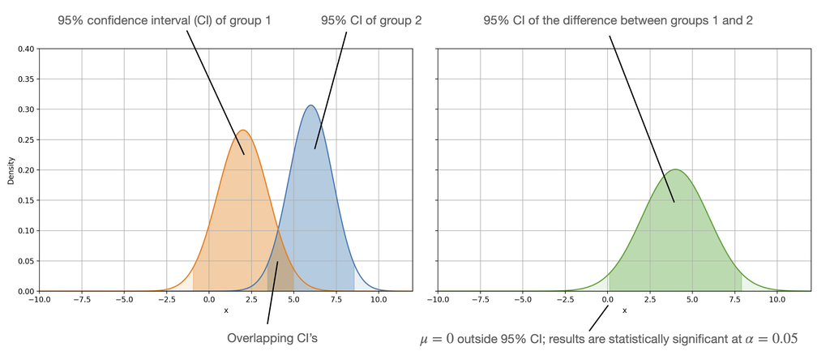

Left: the 95% CIs of two group means overlap. Right: the 95% CI of the difference between those same groups excludes 0, so the difference is significant at α = 0.05. Look at the green plot (right) the shaded interval does not reach zero, so *“no difference”* is not a plausible value for the population mean difference, which is the same conclusion as p < 0.05. For a one-sample test the logic is identical, except we check whether the hypothesised value (μ₀) lies inside the CI of the sample mean.

**Effect size**

A p-value tells you whether the difference is unlikely to be chance; **Cohen’s d** tells you how big it is, in standard-deviation units:

$$d = \frac{\text{mean difference}}{\text{SD}}$$

Because d is standardised (analogous to a z-score), an 8-point focus change on a 100-point scale and a 0.5-s change in reaction time can be compared directly, which is what makes **meta-analysis** possible, by pooling and comparing results across studies even when they measured the outcome on different scales or in different units.

| d | Label |
| --- | --- |
| ≈ 0.2 | Small |
| ≈ 0.5 | Medium |
| ≥ 0.8 | Large |

**What d actually describes.** Picture the histogram (with its density curve) of each group’s scores, as Jamovi draws them, side by side on the same axis. Cohen’s d is the distance between the two peaks measured in standard deviations, the typical spread of each histogram. That ratio decides how much the two groups overlap. At d = 0.2 (small) the two histograms sit almost on top of each other; at d = 0.8 (large) you can see the separation at a glance. You met the same idea in Week 2: Pearson’s *r* is also an effect size (0.1 / 0.3 / 0.5 for small / medium / large), just for relationships instead of group differences. Task 4 lets you visualise the overlap of Cohen’s d.

Two rules for today. **1)** If p > 0.05, interpret d with great caution (or not at all), as you haven’t shown that the means differ, so there is no difference for d to describe the size of. **2)** Effect size ≠ clinical meaningfulness. Whether a difference *matters* needs domain knowledge or is already a standard value e.g., what patients can notice, what guidelines say, a cost threshold. A “small” d can matter (e.g., 25 min less sleep every night) and a “significant” difference can be irrelevant (e.g., a 1.4-point change on a scale where people only begin to notice a change of about 5).

## Get the Jamovi data files

[figure not shown]

Three datasets, one for each type of t-test. Save them somewhere easy to find, then open each in Jamovi when its task comes up.

- Task 1: [**student_sleep.csv**](https://lms.griffith.edu.au/courses/32192/files/10008969?wrap=1) — 57 students, `Sleep (h)`
- Task 2: [**coffee_stress.csv**](https://lms.griffith.edu.au/courses/32192/files/10008970?wrap=1) — 66 students, `Group` (Coffee / NonCoffee) and `VAS Stress 0-10 Score (mm)`
- Task 3: [**music_focus.csv**](https://lms.griffith.edu.au/courses/32192/files/10008972?wrap=1) — 22 students, `Silence` and `Music` focus scores (out of 100)

In each file, check the Variables tab first. The outcome should be *Continuous*, `Group` should be *Nominal*, and `ID` should be *ID*. Jamovi guesses, and it often guesses wrong.

## Research questions

> 1. Do university students get the recommended **7 hours** of sleep per night during exam period?
> 2. Is there a difference in **perceived stress** between regular coffee drinkers and non-coffee drinkers?
> 3. Is there a difference in **focus scores** when studying with music versus in silence?

## Tasks for you to do

Work through these in Jamovi in order and **check your answers as you go**. Each task has small answer boxes, type (or select) what you found and press **✓ Check**. As usual, you get instant feedback, and a hint appears if you’re stuck after a couple of tries. The full **worked answer** for each task stays locked until you answer correctly (a *reveal* option appears after three attempts, so have a genuine go first). A fully worked version with every Jamovi task/test will be released on Canvas after all lab classes finish for the week.

### Task 1 — One-sample t-test: are students getting enough sleep?

[figure not shown]

**Scenario.** The Sleep Health Foundation recommends adults get at least **7 hours** of sleep a night. You’ve collected sleep data from 57 university students during exam period. Are they meeting the recommendation? For judging whether any shortfall *matters*: sleep research links even 20–30 minutes less sleep a night, sustained over weeks, to measurably poorer concentration, mood and wellbeing.

- **H₀:** μ = 7.0 h (students get the recommended amount of sleep)
- **Hₐ:** μ ≠ 7.0 h (two-tailed)

**a) Explore and check assumptions.** Open `student_sleep.csv` in Jamovi. Run **Exploration ▸ Descriptives** on `Sleep (h)`: under *Statistics* tick **Shapiro–Wilk** and **Confidence interval** (for the mean); under *Plots* tick **Histogram** (+ Density), **Box plot** and **Q-Q**. Is the distribution roughly bell-shaped? Do any values look like entry errors (a 14-hour night, a negative number)? Outliers on their own aren’t an assumption of the t-test, so a few points beyond the whiskers are not a problem, you’re just doing the usual checks before we run the analysis.

**b) Run the test.** **Analyses ▸ T-Tests ▸ One Sample T-Test**:

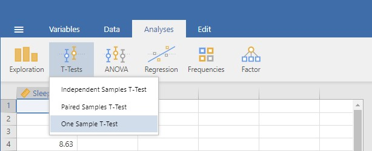

From your Descriptives:

N (students):

Mean sleep (h):

SD (h):

**Hint:** Exploration ▸ Descriptives with `Sleep (h)` in Variables. Tick *Shapiro* under Statistics ▸ Normality. A large p here is *good* news for the assumption.

Assumption check locked. Answer correctly above to unlock it.

**NoteWorked answer — descriptives & assumptions**

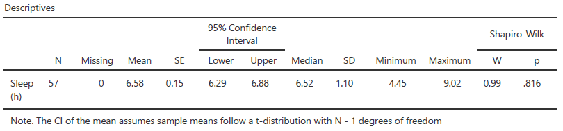

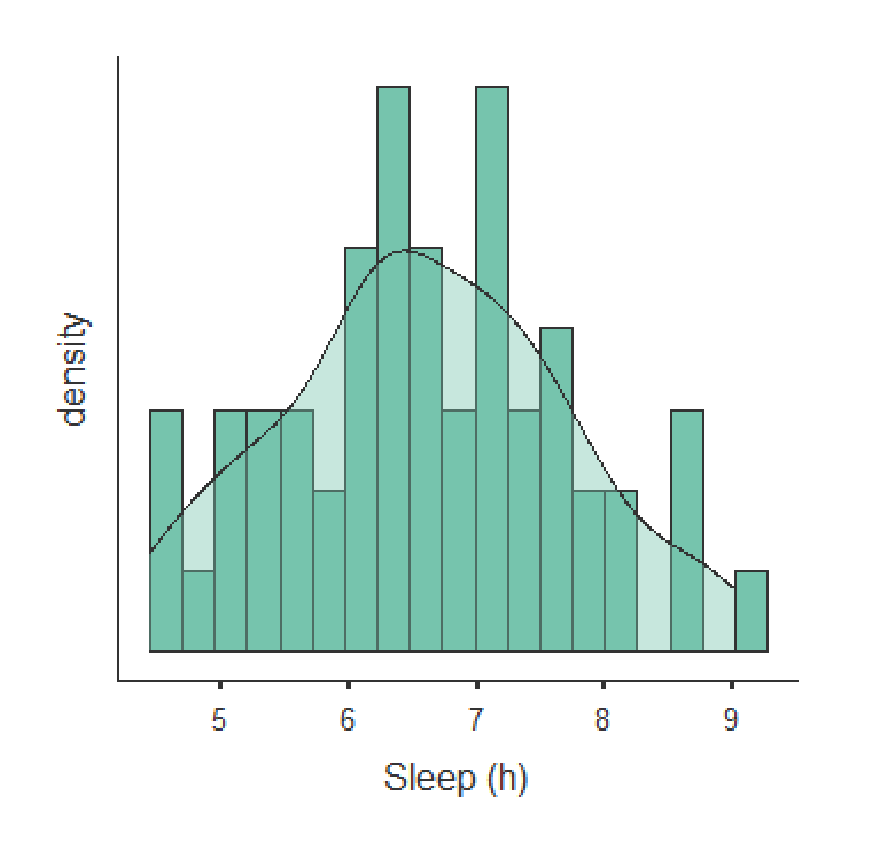

Histogram

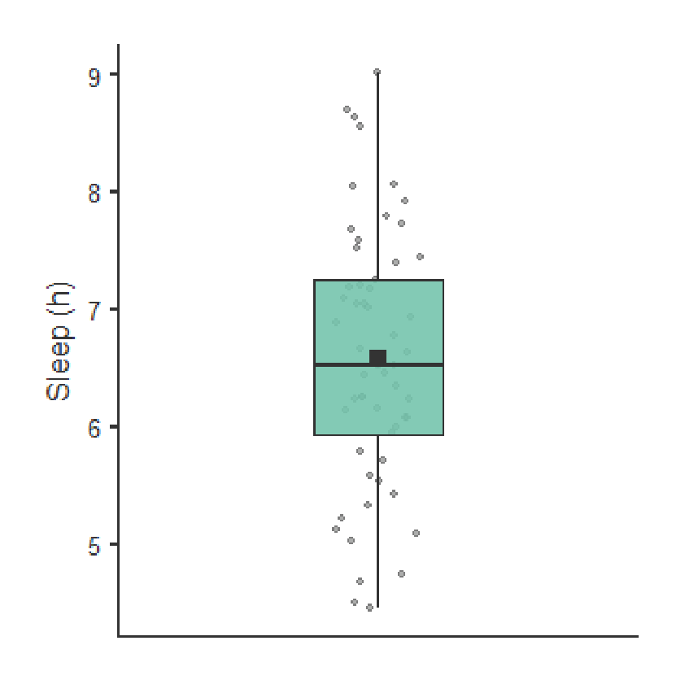

Box plot

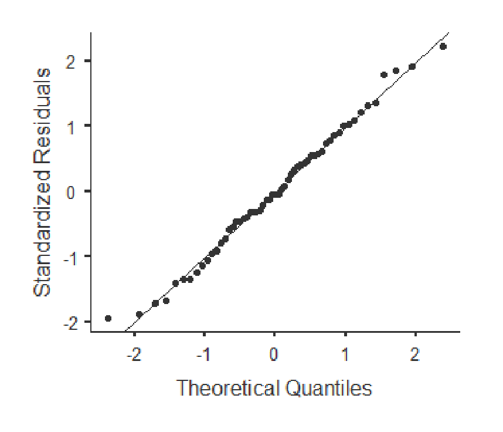

Q-Q plot

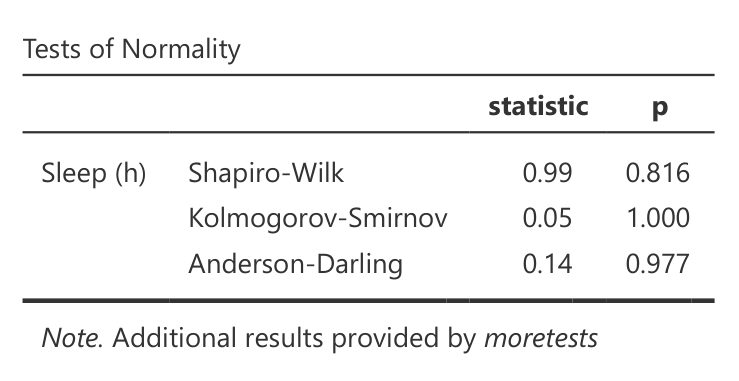

Normality tests

Bell-shaped histogram, no outliers beyond the boxplot whiskers, Shapiro–Wilk p = 0.816 (no evidence against normality) and Q-Q dots tracking the diagonal. **Normality ✓.** Continuous outcome ✓; independence from the design (each row is one student) ✓. Safe to run a t-test.

Also notice the **95% CI of the mean** in this table **[6.29, 6.88]**. It doesn’t contain our reference value of 7 h. File that away, it already tells you how the test is going to go.

Build the interpretation. Use your One Sample T-Test table to choose the right words (the numbers are given; the judgement is yours):

A one-sample t-test compared students’ sleep during exam period (x = 6.58 h, s = 1.10, n = 57) with the recommended 7 h. On average students slept the recommendation, and the difference was at α = 0.05, t(56) = −2.85, p = 0.006, so we . The 95% CI for the mean difference, [−0.71, −0.12] h, 0, which the p-value. Cohen’s d = −0.38 is a effect. Because 0.42 h is about 25 minutes of lost sleep every night of exam period, the shortfall is for student health.

**Hint:** every choice comes from one row of the t-test table. Sign of the mean difference → direction. p vs 0.05 → significant and the H₀ decision (we never “accept” H₀). Does 0 sit between Lower and Upper? d against 0.2 / 0.5 / 0.8. Then ask whether 25 minutes a night would matter to a health professional.

**c) One tail or two?** The research question says “getting *enough* sleep”, which sounds directional. In the dialog, change *Hypothesis* from **≠ Test value** to **< Test value** and watch the p-value.

What happens to p when you switch to the one-tailed (< 7) hypothesis?

It halves (0.006 → 0.003); t and the mean difference don't change It doubles (0.006 → 0.012) Nothing changes; the hypothesis setting only relabels the table

**Hint:** Lecture 12: a two-tailed test splits α = 0.05 into 0.025 per tail. A one-tailed test puts all 0.05 in one tail, so the same result gets a smaller p.

**So why don’t we just use one tail?** Because the direction must be justified *before* seeing the data, a one-tailed test can never detect a surprise in the other direction, and readers (and markers) are rightly suspicious of a result that is only significant one-tailed. Two-tailed is the conservative default in this course; report a one-tailed test only when you pre-specified it and can defend it.

Worked answer locked. Complete the interpretation correctly to unlock it.

**NoteWorked answer — the test**

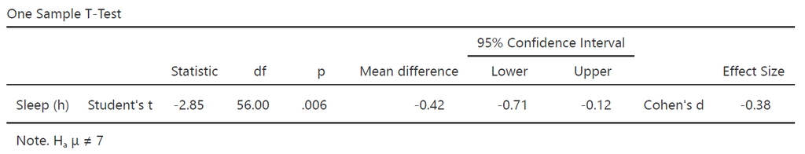

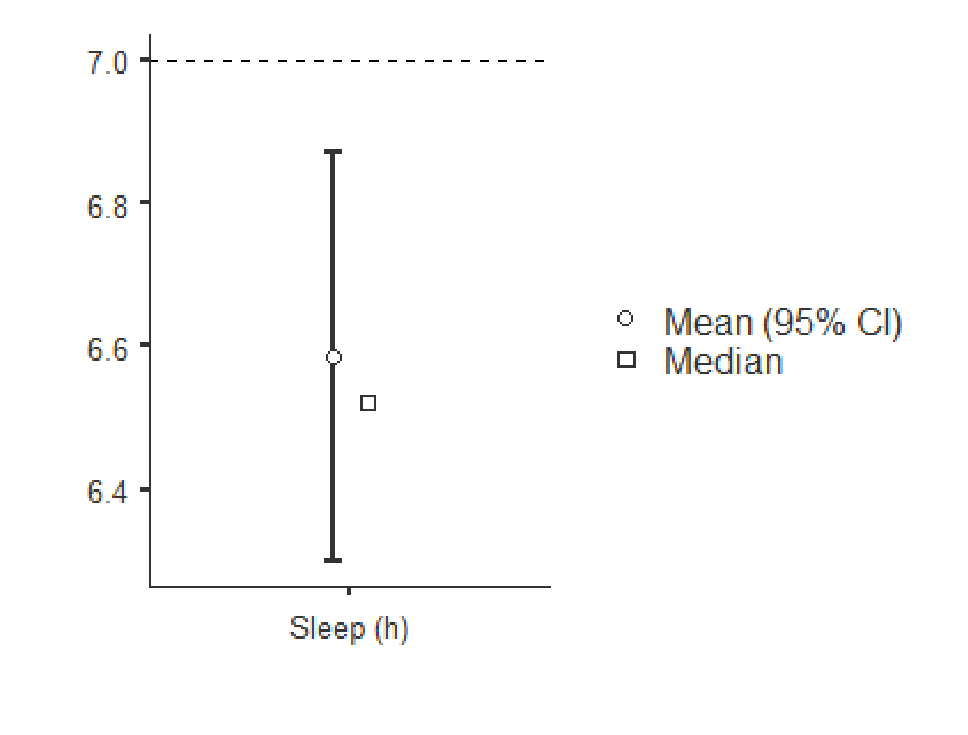

Now the four interpretation questions:

**Significance.** t(56) = −2.85, p = 0.006 < 0.05 therefore we can **reject H₀**. Students’ sleep differs significantly from the 7-hour recommendation, and the negative test statistics and mean difference says they get *less*.

**Confidence interval.** The difference is plausibly anywhere from **0.12 to 0.71 h below** 7 h. The interval doesn’t include 0, which is the same decision as the p-value. Equivalently, the CI for the mean [6.29, 6.88] doesn’t include 7. Look at your descriptive plot: the whole error bar sits under the 7-h line.

**Effect size.** d = −0.38, a **small-to-medium** effect. The students are about 0.4 SD short of the recommendation.

**Clinical meaning.** 0.42 h is about **25 minutes** a night, every night of exam period. Let’s say research links 20 minutes of chronic short sleep to poorer cognition, mood and wellbeing, so despite the modest d this is probably a **meaningful** shortfall and would justify sleep hygiene and exam-stress interventions.

Notice how the effect size and the clinical judgement pull in slightly different directions here (statistically “small”, practically important). That’s normal; the two are related but not the same thing. Sometimes you will see the opposite, a large statistical effect and small p-values but it doesn’t mean anything clinically.

### Task 2 — Independent samples t-test: coffee and stress

[figure not shown]

**Scenario.** Many students lean on caffeine during the trimester. Does regular coffee drinking go with different stress levels? You have perceived-stress scores (visual analogue scale, 0–10) from 33 regular coffee drinkers and 33 non-drinkers. For context, on this scale a change of about **1 point** is roughly the smallest difference students report noticing in how stressed they feel; smaller gaps are unlikely to matter day to day.

- **H₀:** μ<sub>Coffee</sub> = μ<sub>NonCoffee</sub> (no difference in mean stress)
- **Hₐ:** μ<sub>Coffee</sub> ≠ μ<sub>NonCoffee</sub> (two-tailed)

**a) Explore and check assumptions, per group.** Open `coffee_stress.csv` in Jamovi. **Exploration ▸ Descriptives**: put `VAS Stress 0-10 Score (mm)` in *Variables* and `Group` in **Split by**. Tick **Shapiro–Wilk** and **Confidence interval** (for the mean), and under *Plots* the **Histogram** (+ Density), **Box plot** and **Q-Q**.

**b) Run the test.** **Analyses ▸ T-Tests ▸ Independent Samples T-Test**:

1. `VAS Stress 0-10 Score (mm)` → **Dependent Variables**; `Group` → **Grouping Variable**
2. *Tests*: keep **Student’s**
3. *Additional Statistics*: tick **Mean difference**, **Confidence interval**, **Effect size**, **Descriptives** and **Descriptives plots**
4. *Assumption Checks*: tick **Homogeneity test** (Levene’s)

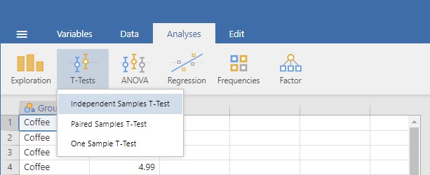

**The extra assumption for two groups.** Student’s t assumes the two groups have roughly **equal variances** (it pools them). Levene’s test checks this… p > 0.05 then it’s fine, you can use Student’s. If Levene’s p < 0.05, tick **Welch’s** under *Tests* and report that row instead; Welch’s doesn’t assume equal variances and adjusts the df (usually to a non-integer). Here the SDs look a little different (1.52 vs 1.17) so worth double checking.

From your split Descriptives:

Mean stress, Coffee:

SD, Coffee:

Mean stress, NonCoffee:

SD, NonCoffee:

Levene's test p:

**Hint:** with `Group` in *Split by*, the Descriptives table has one row per group. Two decimal places is plenty. Levene's p is in the *Homogeneity of Variances Test* table under the t-test output.

Assumption check locked. Answer correctly above to unlock it.

**NoteWorked answer — descriptives & assumptions**

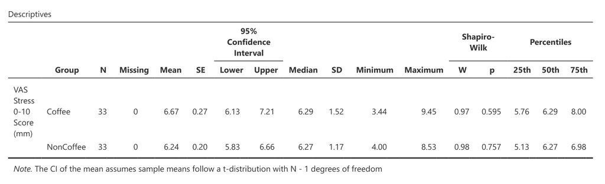

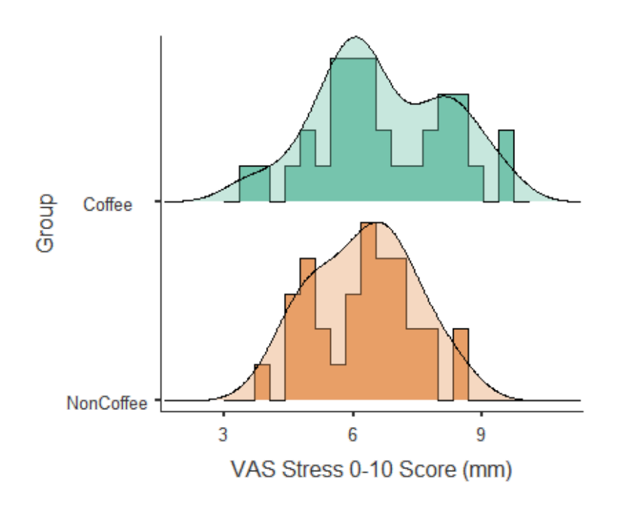

Density by group

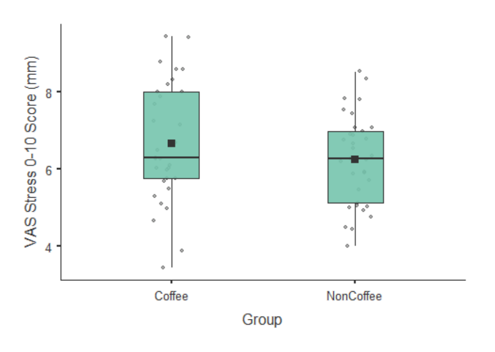

Box plots by group

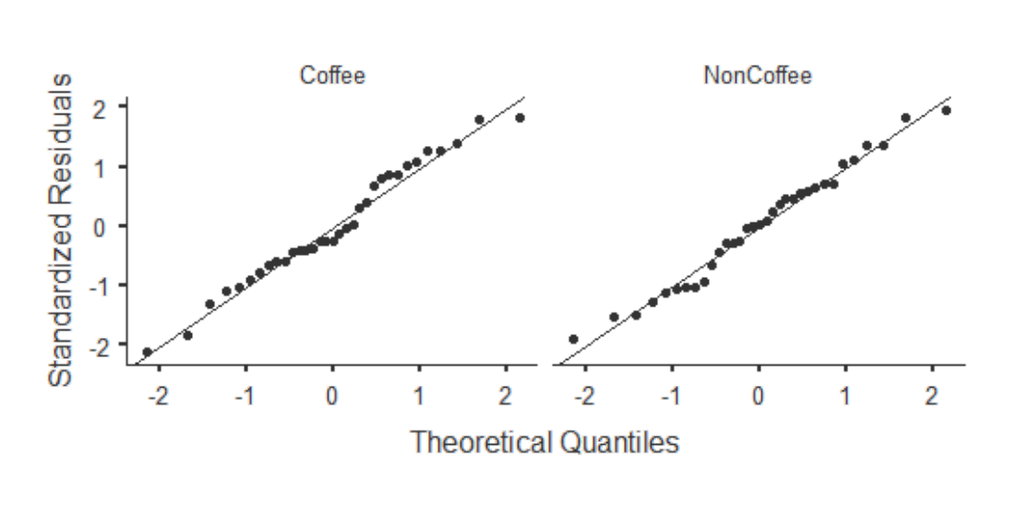

Q-Q plots by group

Coffee drinkers have a marginally higher mean and a wider spread; no outliers in either boxplot. Both Shapiro–Wilk tests are non-significant and both Q-Q plots track the diagonal therfore **Normality ✓** in each group. Levene’s F(1, 64) = 2.50, p = 0.119 suggests **equal variances ✓**, so Student’s t is appropriate (Welch’s gives the same answer anyway: t(60) = 1.29, p = 0.203). Two unrelated groups of 33 so we assume independence ✓. Also note the two groups’ 95% CIs **overlap heavily** (6.13–7.21 vs 5.83–6.66); keep that in mind for the next part.

Build the interpretation from your Independent Samples T-Test table:

An independent samples t-test compared stress between coffee drinkers (x = 6.67, s = 1.52, n = 33) and non-drinkers (x = 6.24, s = 1.17, n = 33). Coffee drinkers scored on average, but the difference was , t(64) = 1.29, p = 0.203, so we . The 95% CI for the difference, [−0.24, 1.10], 0, meaning a true difference of zero . Cohen’s d = 0.32 . The correct conclusion is that this study .

**Hint:** p = 0.203 > 0.05 and the CI straddles 0: the two always agree. “Not significant” means we lack evidence of a difference, not that we have shown there is none. And re-read the Effect size tab about d when p > 0.05.

Worked answer locked. Complete the interpretation correctly to unlock it.

**NoteWorked answer — the test**

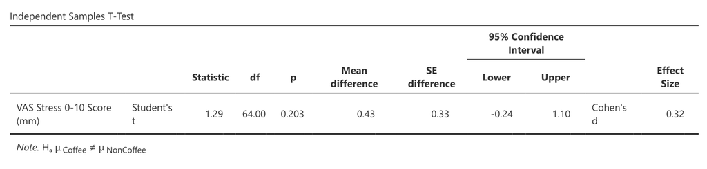

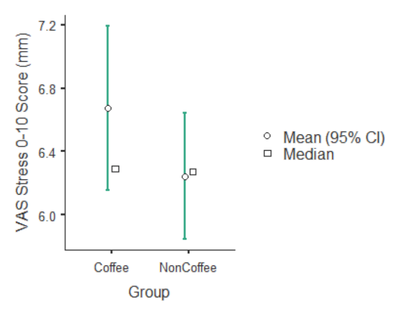

**Significance.** t(64) = 1.29, p = 0.203 > 0.05, so we **fail to reject H₀**. Using intuition, if we think about and unadjusted z cut-off being ±1.96, well a t-statistics of 1.29 is well inside it, so a t cut-off, which only going to be larger, is certainly not going to be crossed.

**Confidence interval.** The true difference could plausibly be anywhere from **0.24 points lower to 1.10 points higher** for coffee drinkers. Because that range **includes 0**, “no difference” is entirely consistent with the data.

**Effect size.** d = 0.32 would be small-to-medium *if* it were real, but we haven’t shown it is. With p = 0.203 (i.e., non-significant) we **don’t really accept the effect size** (though the opposite is true, if we had a small [i.e., significant] p we would interpret the d no matter the size to tell us the size of the effect).

**Clinical meaning.** On a 0–10 stress scale a 0.4-point average gap is unlikely to be noticeable in daily life even if it existed.

**Careful with the wording:** we did *not* prove coffee has no effect. The honest conclusion is that *this study found no evidence of a difference*. To see why the distinction matters, with exactly these means and SDs but **80 per group**, p ≈ 0.047; with **100 per group**, p ≈ 0.026. “Not significant” often just means “not enough data to be sure”, which is why the CI ([−0.24, 1.10], wide) is more honest than the p-value alone as in that hypothetical is means the true population mean could fall either side of zero (we are not sure the direction of the relationship, if any).

**Design check before Task 3.** Even if this had been significant, it would *not* show that coffee causes stress. Students **chose** their group, so coffee drinkers might differ in workload, sleep, income or anxiety to begin with (the confounding problem from the earlier correlation lectures). Compare that with Task 3, where the same students do both conditions in a **counterbalanced experiment**. That design *can* support a causal claim, which is one more reason paired designs are so valuable when they’re feasible.

### Task 3 — Paired samples t-test: music and focus

[figure not shown]

**Scenario.** Does background music help you study? 22 students completed a focus task under two conditions, **silence** and **music**, in counterbalanced order. Each person contributes both scores (out of 100), so the two columns are *paired*. The focus scale was designed so that a change of about **5 points** is the smallest difference students can actually notice in their concentration; keep that benchmark in mind when you judge whether any difference you find is meaningful.

- **H₀:** μ<sub>d</sub> = 0 (no difference in focus between conditions)
- **Hₐ:** μ<sub>d</sub> ≠ 0 (two-tailed)

**a) Create the difference score.** Open `music_focus.csv` in Jamovi. **Data ▸ Compute**, name it `Difference`, formula: `` `Silence` - `Music` ``. A positive difference means the student focused *better in silence*. This is the variable the paired test actually analyses, so it’s the one whose normality matters.

**b) Check assumptions.** **Exploration ▸ Descriptives** on `Silence`, `Music` **and** `Difference` with **Shapiro–Wilk**, **Histogram**, **Box plot** and **Q-Q**. You’ll see a couple of boxplot outliers in the raw scores (IDs 5 and 12); don’t remove them, there’s no reason to think they’re errors and t-tests are robust to a few.

**c) Run the test.** **Analyses ▸ T-Tests ▸ Paired Samples T-Test**:

1. Move **`Silence` first, then `Music`** into *Paired Variables* (so Jamovi reports Silence − Music and the sign matches your `Difference` column)
2. *Tests*: keep **Student’s**
3. *Additional Statistics*: **Mean difference**, **Confidence interval**, **Effect size**, **Descriptives** and **Descriptives plots**

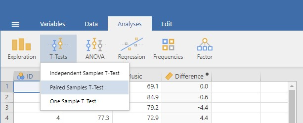

From your Descriptives:

Mean focus, Silence:

Mean focus, Music:

SD of Difference:

Shapiro–Wilk p for Difference:

**Hint:** three rows in Descriptives: Silence, Music, Difference. The Shapiro–Wilk we care about is the *Difference* row.

Assumption check locked. Answer correctly above to unlock it.

**NoteWorked answer — descriptives & assumptions**

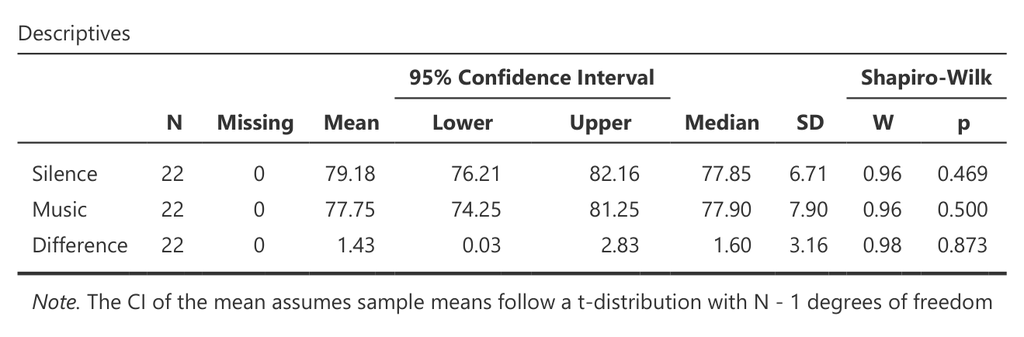

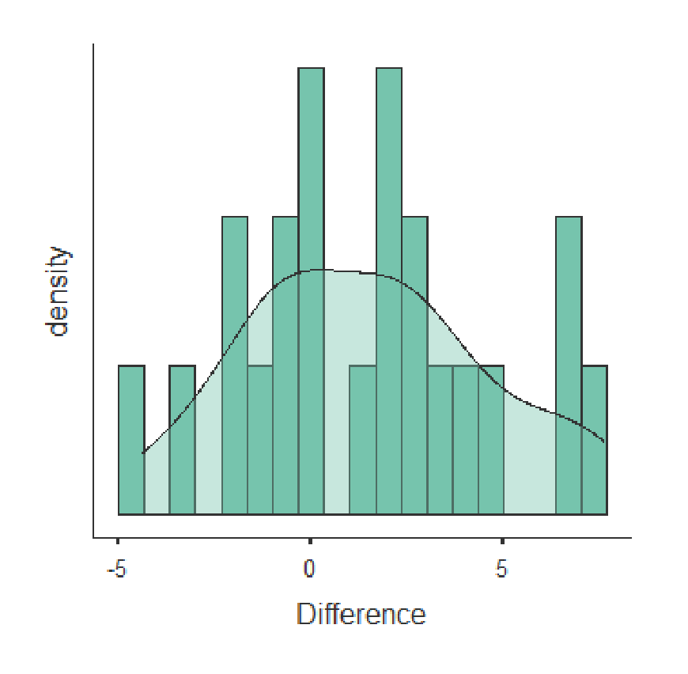

Difference: histogram

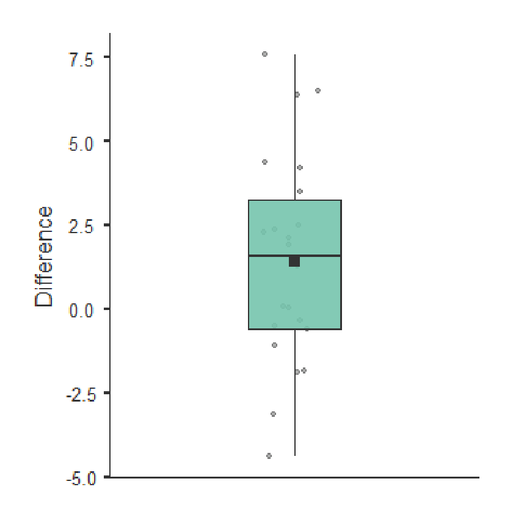

Difference: box plot

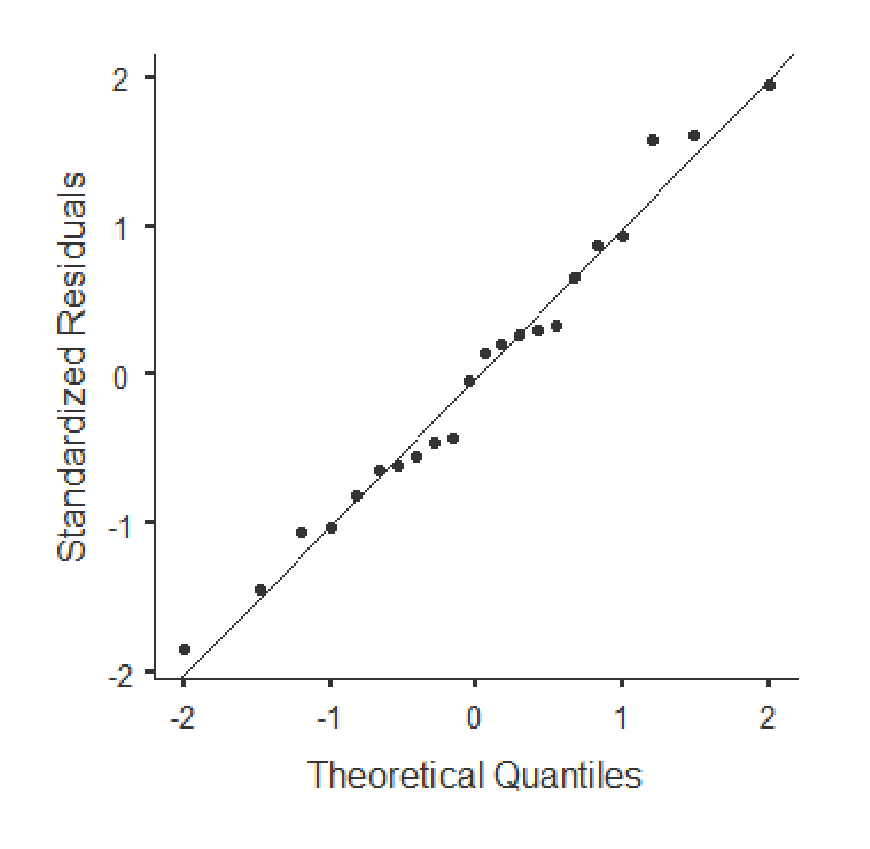

Difference: Q-Q plot

On average students scored **1.43 points higher in silence** than with music, with a lot of person-to-person variation (SD 3.16, some students improved with music, most got slightly worse). The Difference scores are approximately normal (SW p = 0.873, clean histogram and Q-Q) therfore **Normality ✓**. The pairs are independent students ✓.

Build the interpretation from your Paired Samples T-Test table (Silence − Music):

A paired samples t-test compared focus in silence (x = 79.18, s = 6.71) and with music (x = 77.75, s = 7.90) in the same 22 students. Focus was , and the difference was , t(21) = 2.12, p = 0.046, so we . The 95% CI for the mean difference, [0.03, 2.83] points, 0, but its lower limit is zero, so the true effect could be . Cohen’s d = 0.45 is a effect.

**Hint:** p = 0.046 is under 0.05, but only just, and the CI’s lower limit of 0.03 says the same thing. Positive mean difference = silence scored higher (if yours is negative you entered Music first). df = pairs − 1.

The 95% CI for the mean difference is [0.03, 2.83], yet the two groups' own 95% CIs (Silence 76.2–82.2, Music 74.3–81.3) overlap a lot. Which statement is correct?

Because the group CIs overlap, the difference can't be significant The difference is significant: the CI of the *difference* excludes 0, and overlapping group CIs don't rule that out Jamovi has made an error, these two results contradict each other

**Hint:** re-read the warning in the *CIs & p-values* tab. Non-overlapping group CIs guarantee significance; overlapping ones tell you nothing either way. And a paired test removes the between-person variation that makes each group's CI wide.

**Clinical meaningfulness.** The scenario told you the focus scale was designed so that about **5 points** is the smallest change students can actually notice. How should the 1.43-point effect be judged?

Statistically significant and clinically meaningful; students should stop listening to music Statistically significant but not clinically meaningful; too small to warrant changing study habits Not significant, so there's nothing to interpret

**Hint:** compare the mean difference (and even the far end of its CI, 2.83) with the 5-point threshold. p answers "is it there?", the scale answers "does it matter?"

Worked answer locked. Complete the interpretation correctly to unlock it.

**NoteWorked answer — the test**

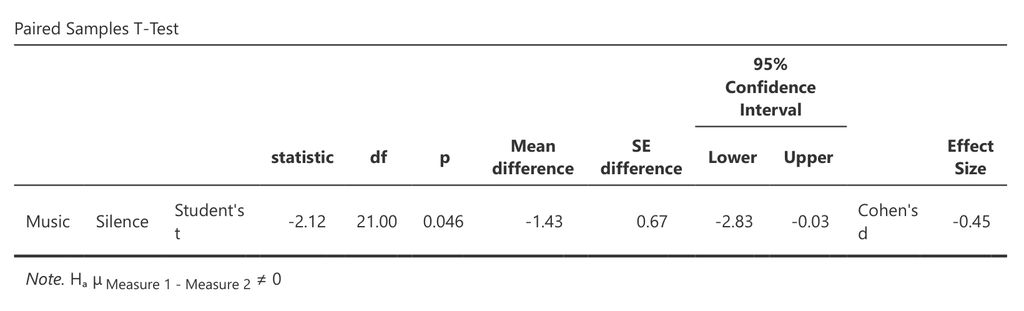

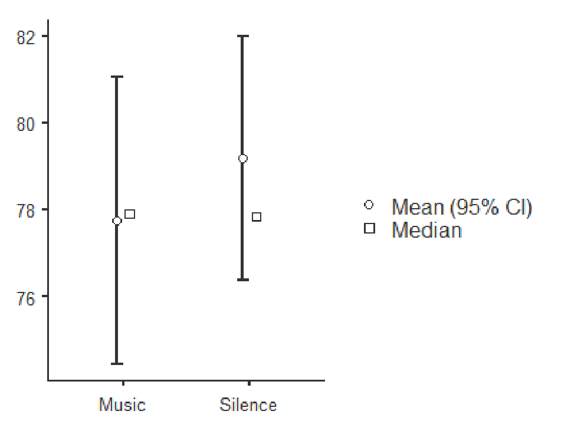

*(This output was produced with the pair entered Music then Silence, so every sign is flipped relative to the table above; the sizes are identical. I did this intentionally to demonstrate that the condition you list first changes the sign but not the conclusion.)*

**Significance.** t(21) = 2.12, p = 0.046 < 0.05 therefore we can **reject H₀**. Focus was significantly *higher in silence* (i.e. lower with music). Only just: p = 0.046 is a whisker under 0.05. Now ask yourself is a probability of 4.6% vs. 5.0% really that different? But magically it is when it comes to interpretation of significant vs non-significant for p-values it is and this is a problem we will cover in later weeks.

**Confidence interval.** [0.03, 2.83] excludes 0, matching the p-value, but its lower end is barely above zero. The true effect could be almost nothing or nearly 3 points.

**Effect size.** d = 0.45, small-to-medium.

**Clinical meaning.** 1.43 points on a 0–100 scale where about 5 points is the smallest noticeable change. Even the most pessimistic end of the CI (2.83) is under that threshold. **Not clinically meaningful**: no reason to tell students to ditch their playlists.

**The overlapping-CI lesson.** The descriptive plot shows two heavily overlapping error bars, yet the test is significant. That’s because the paired design compares each student with *themselves*, stripping out the huge between-person differences (scores range from the 50s to the 90s) that make each group’s CI wide. The within-person differences are much tighter (SD 3.16 vs ~7 for the raw scores), which is exactly why we prefer paired designs when we can get them.

### Task 4 — Visualisation, confidence intervals & effect sizes (if we have time in class)

Three things to notice, in this order:

1. The **sample means pile up around the population mean μ**, and they are far less spread out than the individual scores above them. Their spread is the **standard error of the mean**, and the tool shows it matches σ ÷ √n.
2. **Increase n** and draw again, the pile gets narrower. That is the whole reason larger samples give narrower CIs and smaller p-values.
3. Switch to the **right-skewed** or **bimodal** population and draw a few hundred samples with n = 30. The population is nothing like a bell curve, yet the sampling distribution of the mean is. That is the **Central Limit Theorem**, and it is why the t-test only needs *approximate* normality once samples are moderately large.

**This is where the z, t and F tables come from, and where hypothesis tests come from.** You have just built a sampling distribution by brute force. Statisticians worked out the *exact* shape of these distributions mathematically, for every sample size, and that is what the tables in the lecture (and Jamovi’s p-values) contain: the sampling distribution you would get **if H₀ were true**. The t-table has a row for every df because, once σ has to be estimated from the sample, the shape depends on n, which is why small samples need a bigger t to reach significance.

A hypothesis test is then a simple question: *is my sample mean (or mean difference) a plausible draw from the sampling distribution that H₀ predicts?* If it sits in the middle, H₀ survives. If it sits out in the tail, beyond the critical value, we conclude our sample did **not** come from a population with that mean. For a pre/post weight-loss study, rejecting H₀ says the post-programme weights behave as if they were drawn from a population with a *different* mean to the pre-programme weights, i.e. the programme moved the population mean, not just this sample.

Keep the population the same and change only the sample size from n = 10 to n = 40. After a few hundred draws, what happens to the sampling distribution of the mean?

It stays centred on μ but its spread roughly halves Nothing changes: the population is the same, so the sampling distribution is the same It shifts to a different centre and gets wider

**Hint:** compare the "SD of the sample means" readout at the two sample sizes, and compare both with σ ÷ √n. √40 is twice √10.

Try these in order:

1. Press **Sleep data** and confirm you get the Task 1 numbers (any difference in the last decimal place is rounding).
2. Drop **n to 20** (same mean and SD). Watch the CI widen and swallow the 7-h line: the same 25-minute shortfall is now *not* significant. Small samples can only detect big effects.
3. Reset, then set the **mean to 6.90** (a 6-minute shortfall). Not significant at n = 57. Now push **n** up until the CI just excludes 7. That’s the “big sample makes anything significant” effect from Lecture 12, and why we never stop interpretation at just the p-value.
4. Switch confidence to **99%**. Wider interval, same data.

**By hand, once.** The exam asks you to calculate a CI with a t-table (Lecture 11), so do it once here without the tool. For the sleep data: x̄ = 6.58, s = 1.10, n = 57, so SEM = s ÷ √n. From the t-table, t<sub>0.025, df 56</sub> ≈ 2.003.

95% CI = x̄ ± t × SEM. Fill in the limits to 2 decimal places:

Lower limit:

Upper limit:

**Hint:** margin of error = 2.003 × 0.146 = 0.29. Subtract it from and add it to 6.58.

With mean = 6.90 h and s = 1.10 h, roughly what sample size makes the 95% CI first exclude 7 h (p just under 0.05)?

About 60 About 150 About 480 It never does, the difference is too small

**Hint:** type values straight into the n box rather than dragging. Watch the verdict flip from amber to teal.

Worked answer locked. Answer correctly above to unlock it.

**NoteWorked answer — why n matters**

SEM = s ÷ √n, and the CI is mean ± t<sub>crit</sub> × SEM. Quadrupling n halves the SEM and halves the CI width. With a 0.10-h shortfall you need SEM ≈ 0.05, so √n ≈ 22 → n ≈ 475–480. At that point p ≈ 0.048 and d is a trivial 0.09 (you can check against the visualisation tool).

That result is *statistically* significant and *practically* meaningless (6-minutes of sleep). Compare it with Task 1: a 25-minute shortfall at n = 57 gave p = 0.006 **and** a plausible health impact. Same test but very different stories, which is why the four interpretation questions are asked together and never separately.

The bell curves here, and the density curves in Jamovi’s Descriptives, show the spread of **individual people’s scores** (you can see the people inside them). The t-distribution in the CI lab shows how the **test statistic** would vary across repeat samples if H₀ were true, and the CI figure earlier shows how a **mean** varies across samples. Individuals vary far more than means do, which is why two groups can overlap heavily here (small d) and still have a mean difference whose CI clearly excludes 0.

**Study question.** A researcher finds that students who use social media > 3 h/day have significantly lower GPAs (p = 0.03) but d = 0.15. Press the *Social media* preset button (d = 0.15) and look at the overlap, then choose the best interpretation:

p = 0.03 shows a strong effect of social media on GPA The difference is unlikely to be chance, but it's very small because heavy and light users' GPAs overlap almost entirely d = 0.15 means there's no real difference, so the p-value must be wrong

**Hint:** read the overlap percentage. p and d answer different questions ("is it detectable?" vs "how big?"). A large sample makes a tiny effect detectable.

## Putting it into words

The numbers only matter if you can communicate them. Below is a model write-up for each test, built on the same four-question skeleton, **the test and the descriptives, the statistic with df and p, the CI, the effect size, then the decision and what it means in context.** This is the template for the exam’s short-answer interpretation questions and are the answers to the earlier dropdown interpretation questions.

> **One-sample.** A one-sample t-test compared students’ sleep during exam period (x = 6.58 h, s = 1.10, n = 57) with the recommended 7 h. Students slept significantly less than recommended, t(56) = −2.85, p = 0.006, mean difference −0.42 h, 95% CI [−0.71, −0.12], d = −0.38. Although the effect size is small-to-medium, a shortfall of ~25 min per night is consistent with impairments in cognition and mood, so the finding is practically meaningful and supports sleep interventions during exam periods.

> **Independent samples.** An independent samples t-test compared perceived stress between coffee drinkers (x = 6.67, s = 1.52) and non-drinkers (x = 6.24, s = 1.17). There was no significant difference, t(64) = 1.29, p = 0.203, mean difference 0.43, 95% CI [−0.24, 1.10]. Because the interval includes zero, the data are consistent with no difference; the observed d = 0.32 should not be interpreted as evidence of an effect.

> **Paired samples.** A paired samples t-test compared focus scores when studying with music (x = 77.75, s = 7.90) versus in silence (x = 79.18, s = 6.71) in 22 students. Focus was significantly lower with music, t(21) = 2.12, p = 0.046, mean difference (silence − music) 1.43, 95% CI [0.03, 2.83], d = 0.45. However, the difference is well below the ~5-point change students can perceive, so while statistically significant it is not practically meaningful.

### The same tests in real research (optional reading)

If you want to see how these write-ups look in published work, here are three open-access papers, one from each of your disciplines, that lean on exactly today’s tools. In each case the *Results* section is short enough to read in five minutes; look for the mean(s), the mean difference, the CI, the p-value and the effect size, and ask the four interpretation questions yourself.

**Pharmacy · paired samples t-test.** Gan et al. (2025) trained 18 Malaysian community pharmacists to deliver HIV PrEP services and tested their knowledge before and after an online course. Each pharmacist is their own control, so the pre/post scores are paired. Mean knowledge rose from 64.7% to 78.9%, a mean increase of 14.2 percentage points with a 95% CI of 8.2 to 20.1, p < 0.001 (paired t-test). **Notice,** the CI is nowhere near 0, so the p-value adds little; the CI is the more informative number. Also notice int he full paper they went looking for who *didn’t* improve (four mid-career pharmacists), which is a clinical-meaning question they were interested in. [PubMed 40824910 · PLOS ONE](https://pubmed.ncbi.nlm.nih.gov/40824910/)

**Exercise science · independent samples t-test.** Dello Iacono et al. (2022) compared force output on an isometric horizontal push test between 16 football players and 16 recreationally active university students. Two separate groups, therefore independent samples. Footballers produced 10.09 ± 1.57 N/kg versus 6.18 ± 0.89 N/kg in controls, p < 0.001, with an effect size of g = 3.2 (“large”). **Notice,** the effect size is reported as Hedges’ g, which is Cohen’s d with a small correction for small samples (read it exactly as you would d). With means over 3 SDs apart the two groups barely overlap at all; put d = 2 into the visualiser slider above to get a feel for where 3.2 would be. Also note the SDs differ a bit between groups (1.57 vs 0.89), so this is a case where you’d want to see Levene’s test and likely run a Welch’s t-test (not Student’s t-test). [PubMed 35959334 · Biology of Sport](https://pubmed.ncbi.nlm.nih.gov/35959334/)

**Clinical exercise physiology · paired samples t-test (crossover).** Saiphoklang et al. (2022) asked whether the corridor length used for the six-minute walk test (6MWT) changes the result (6MWT is a clinical tool for exercise capacity in frail/diseased individuals). Fifty patients with COPD walked both a 20-m and a 30-m course in randomised order (a counterbalanced crossover, exactly like Task 3). Mean ± SD distances were 337.8 ± 71.8 m on the 20-m course and 359.9 ± 77.3 m on the 30-m course. There was a mean difference of 22.0 m, 95% CI 15.8 to 28.3 m, p < 0.001 between groups. **Notice,** the clinical-meaning step reported, the smallest change in 6MWD that matters to COPD patients is usually quoted at around ~30 m, and the whole CI sits just under that. The authors’ conclusion, that walkway length matters and the 30-m course (standard) should be kept. This conclusion rests on the size of the difference relative to that threshold, not on the p-value alone. If the CIs captured 30 m toward the middle these two courses (20-m or 30-m) might be interchangable. [PubMed 34995334 · PLOS ONE](https://pubmed.ncbi.nlm.nih.gov/34995334/)

**Why no one-sample example?** They’re rare in published research. Studies almost always have a comparison group, and a trustworthy population reference value is hard to come by. Where one-sample tests do appear it is usually to compare a clinical group with a normative or age-predicted value (e.g. patients’ VO₂peak as a percentage of predicted), which is exactly the sleep-vs-7-hours logic from Task 1.

**Looking ahead we need to consider multiple comparisons.** Each study today asked *one* question, so α = 0.05 was fine. If you tested whether music affects focus **and** stress **and** memory (three tests on the same data), the chance of at least one false positive rises to about 14%. An upcoming lecture covers how to adjust α for that. This is a common mistake in published research.

## How this links to assessment

- The workflow today (assumptions → hypotheses → test → CI → effect size → interpretation) is the frame for **every** test for the rest of the trimester and for the **exam**.
- The exam will give you Jamovi output like today’s and ask you to **choose the right test from a scenario**, **read the table** (t, df, p, CI, d) and **write the interpretation**, including whether a result is practically meaningful.
- And most immediately… the group activity (next) counts towards your **Portfolio of Evidence** and has lab-specific questions.

## That’s it for Jamovi today.

[figure not shown]

**Now gather your team for the group Portfolio of Evidence activity (20 mins).**

- Put all phones, laptops, electronic devices away
- Turn off the lab computers
- You can have a calculator, ruler, pen
- You can write/draw on the exam sheet
- Please include all names and s numbers for all group members
- 1 mark for first correct scratch, 1/2 mark for second, 1/4 for third, 0 for forth
- Work together as a team :)

## Getting help

During the session I’ll circulate to help, don’t be afraid to ask. After the workshop, revisit this page, check your module notes for interpretation help, or post in the Microsoft Teams channel, email me, or [**book an office hours meeting**](https://lms.griffith.edu.au/courses/32192#cc-collection-4).

## References

[1] The jamovi project (2024). *jamovi.* (Version 2.6) [Computer Software]. Retrieved from https://www.jamovi.org.

[2] R Core Team (2024). *R: A Language and environment for statistical computing.* (Version 4.4) [Computer software]. Retrieved from https://cran.r-project.org.

[3] Cohen, J. (1988). *Statistical power analysis for the behavioral sciences* (2nd ed.). Lawrence Erlbaum Associates.

[4] Gan, Y. N., Zaki, R., Hafidzar, S. A., et al. (2025). Development and evaluation of an online HIV pre-exposure prophylaxis (PrEP) training program for community pharmacists to implement pharmacy-led PrEP services in Malaysia. *PLOS ONE, 20*(8), e0328713. https://doi.org/10.1371/journal.pone.0328713

[5] Dello Iacono, A., Holgado Lopez, C., Bakhshi, A., & Halperin, I. (2022). The isometric horizontal push test correlates with jumping and sprinting performance among athletes and recreationally active controls. *Biology of Sport, 39*(3), 555–562. https://doi.org/10.5114/biolsport.2022.106158

[6] Saiphoklang, N., Pugongchai, A., & Leelasittikul, K. (2022). Comparison between 20 and 30 meters in walkway length affecting the 6-minute walk test in patients with chronic obstructive pulmonary disease: A randomized crossover study. *PLOS ONE, 17*(1), e0262238. https://doi.org/10.1371/journal.pone.0262238

[7] Magnusson, K. (2023). *Interpreting Cohen’s d effect size: An interactive visualization* (Version 2.6.0) [Web app]. R Psychologist. https://rpsychologist.com/cohend/

*Document prepared by Aaron Bach using Quarto.*